# ggplot2 minimal script

Ashley Sawle

Last modified: 26 Apr 2019

## Introduction

**Tidy Data**

1. variable - column
2. observation - row
3. value - cell

### Load the tidyverse

**conflicts - e.g `filter`**

### Read in the patient data

**tsv**

- `readr` vs base R equivalents - **faster; tibbles; character not factors; column names**

### View the patients dataset

```r
class(patients)
```

Printing tibble

```r
patients
```

**This dataset required cleaning**

*What are the variables in the patients dataset? What are the observations?*

*What types of variables do we have?*

```r
class(patients$Sex)
```

*What types should each variable be?*

- **Categorical: Sex, Smokes, State** or **Continuous: Height, Weight, BMI**
- *Do any need to be changed?*
- *What about Grade or Age?* - **Categorial or ordinal**
- **Factors for Ccategorical** - fixed set of possible values **levels**

### e.g Sex to Factor

```r
patients$Sex <- factor(patients$Sex)
patients$Sex
levels(patients$Sex)
patients
```

### do for mulitple - **`mutate_at`**

```r
patients <- mutate_at(patients, vars(Sex, Smokes, State, Grade, Age), factor)
```

## Our first ggplot - a scatter plot Height v Weight

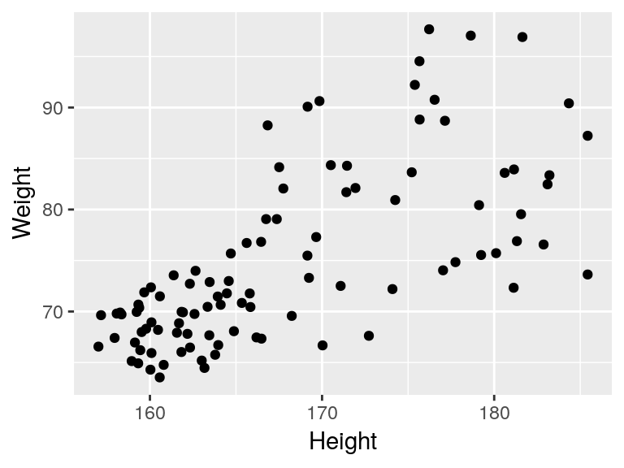

**3** things:

1. The data (**data frame**)
2. The type of plot (**geom** - geom_point)
3. The mapping (**aesthetics** - x and y) others ….

```r
?geom_point
```

## Other Aesthetic mappings

What about those other aesthetics? **Look in help**

### Colour

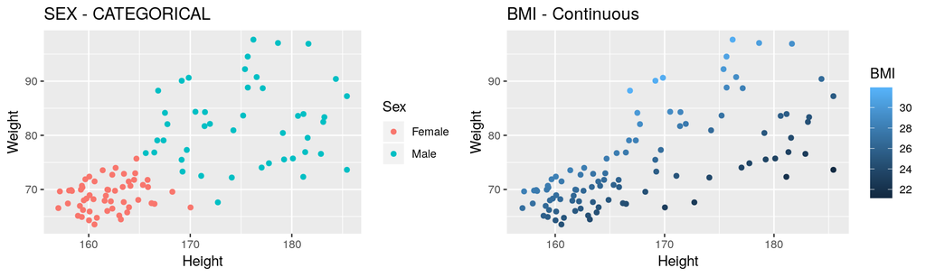

### Shape by sex

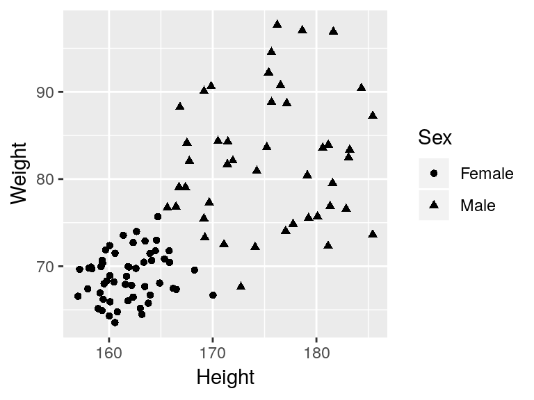

#### **can only be categorical - TRY BMI**

`Error: A continuous variable can not be mapped to shape`

### Size

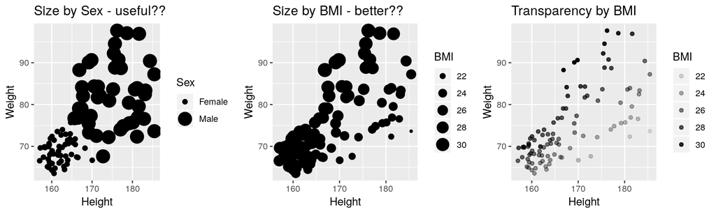

## Customization

**ggplot chooses the colours etc automically but we can customize**

## ggplot2 grammar

The “gg” in ggplot2 stands for “grammar of graphics”. This grammar is a coherent system for describing and building graphs.

The basic template is:

```
ggplot(data = <DATA>) +
  <GEOM_FUNCTION>(mapping = aes(<MAPPINGS>))
```

This template can be used to create any of the different types of graph possible with ggplot2.

## What Other plots

- **Package tab**
- **Cheat Sheet**
- **Web**

## bar chart of patient’s ages.

```
## $title
## [1] "single categorical variable mapped to `x`"
##
## attr(,"class")
## [1] "labels"
```

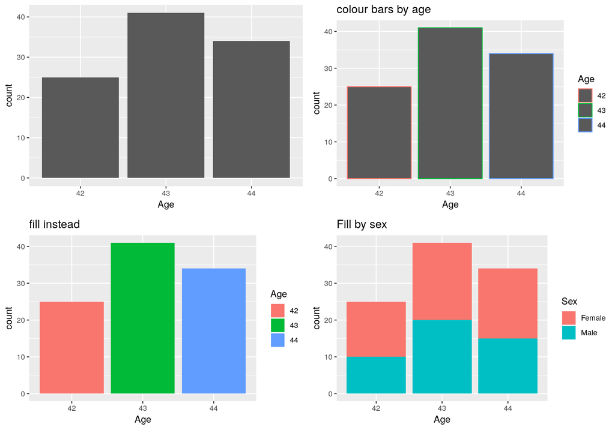

*`position="dodge"`*

### All bars blue

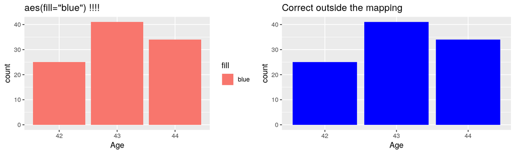

## Multiple layers

```
ggplot(data = <DATA>) +
  <GEOM_FUNCTION>(mapping = aes(<MAPPINGS>))
```

Why do we have the ggplot part and geom part joined by a “+” symbol?

**multiple geoms - different layers**

### points and smooth Height v Weight

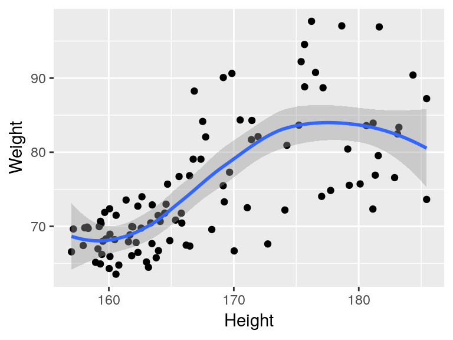

**`geom_smooth` help page** - is not very simple!!!

**shaded area = standard error**

## Global mappings…

**mappings in the `ggplot` function**

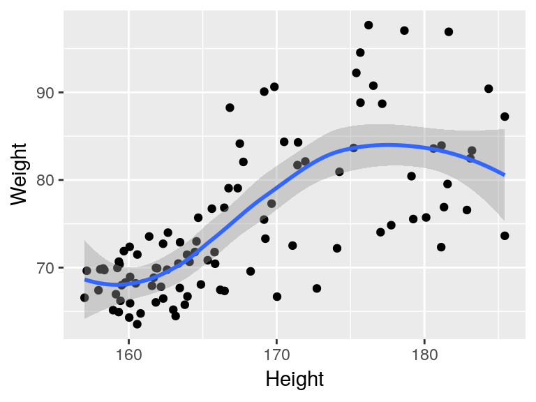

```r
ggplot(data = patients, mapping = aes(x = Height, y = Weight)) +
  geom_point() +
  geom_smooth()
```

### Try to colour the points by sex.

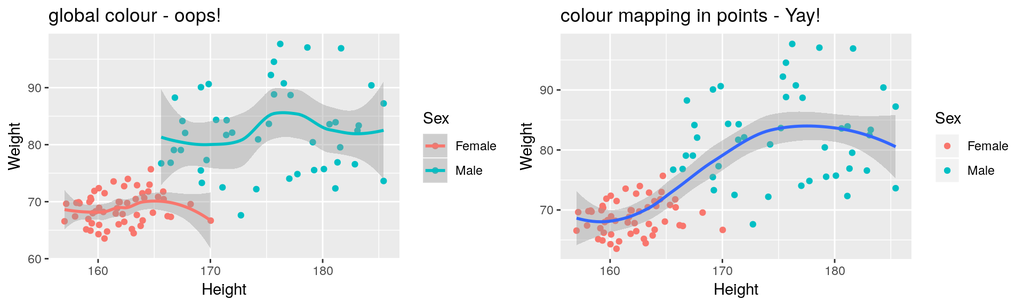

#### **`inherit.aes = FALSE`**

```r
ggplot(data = patients, mapping = aes(x = Height, y = Weight, colour = Sex)) +
  geom_point() +
  geom_smooth(mapping = aes(x = Height, y = Weight), inherit.aes = FALSE)
```

## Line plot

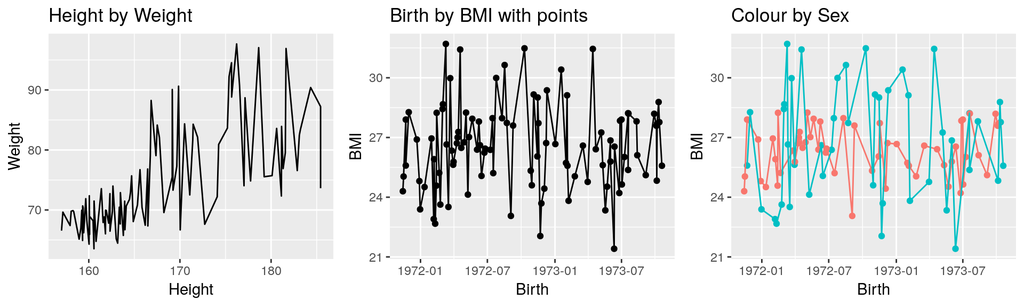

**clever with dates - `lubridate`**

## Histogram

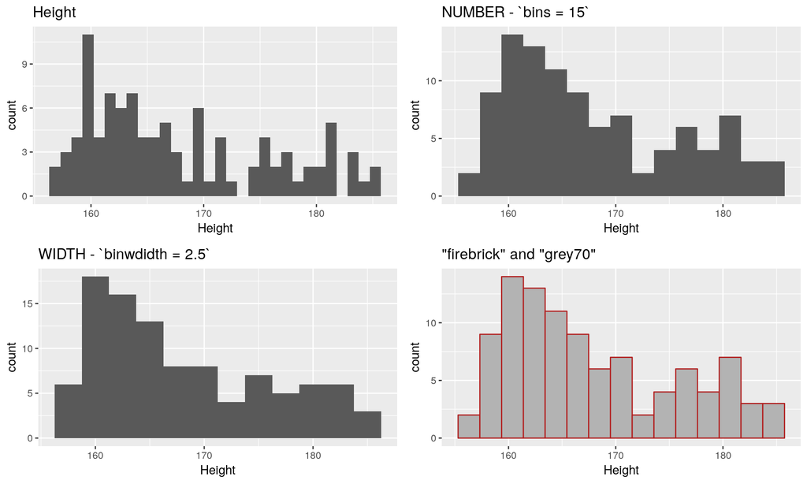

### alternative **geom_freqpoly**

*When might this be preferred?*

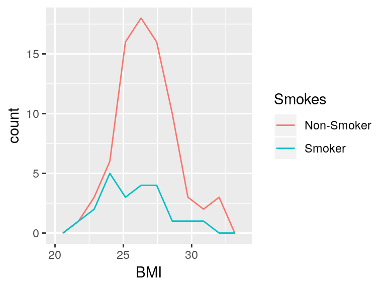

```r
ggplot(data = patients) +
  geom_freqpoly(mapping = aes(x = BMI, colour = Smokes), bins = 10)
```

## Box plot

**EXPLAIN box and whiskers**

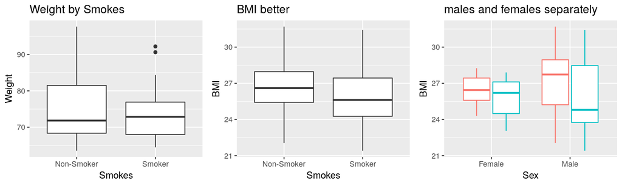

### Add points

[figure not shown]

### Violin plot

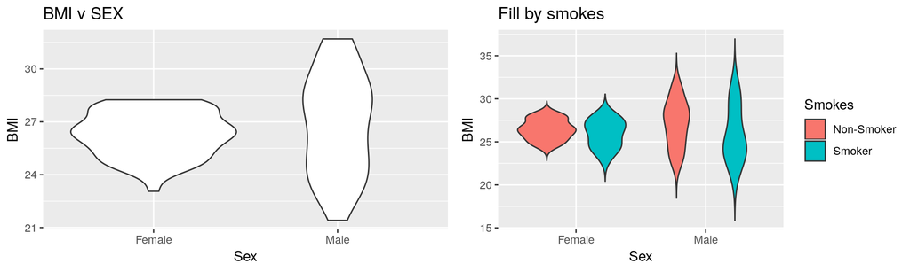

### Density plot

Deliberately not covering this here as it is required for a couple of the exercises and we want you to work it out for yourself using the help pages and what you’ve learned so far about the common grammar for all ggplots.

## The ggplot object - a peek under the hood

Let’s the build the plot up in stages.

What is the plot object we’ve just created?

Look at the environment pane in RStudio (usually in top right corner). The plot object is a list of 9.

```
## [1] TRUE
```

It’s actually a special type of list.

```
## [1] "gg"     "ggplot"
```

What are the 9 things in the list?

```
## [1] "data"        "layers"      "scales"      "mapping"     "theme"
## [6] "coordinates" "facet"       "plot_env"    "labels"
```

So far we’ve constructed ggplots from data, layers (geoms) and aesthetic mappings. We’ll be looking at how to customize plots later, including changing the labels, scales and theme.

```
## # A tibble: 100 x 15
##    ID    Name  Sex   Smokes Height Weight Birth      State Grade Died
##    <chr> <chr> <fct> <fct>   <dbl>  <dbl> <date>     <fct> <fct> <lgl>
##  1 AC/A… Mich… Male  Non-S…   183.   76.6 1972-02-06 Geor… 2     FALSE
##  2 AC/A… Derek Male  Non-S…   179.   80.4 1972-06-15 Colo… 2     FALSE
##  3 AC/A… Todd  Male  Non-S…   169.   75.5 1972-07-09 New … 2     FALSE
##  4 AC/A… Rona… Male  Non-S…   176.   94.5 1972-08-17 Colo… 1     FALSE
##  5 AC/A… Chri… Fema… Non-S…   164.   71.8 1973-06-12 Geor… 2     TRUE
##  6 AC/A… Dana  Fema… Smoker   158.   69.9 1973-07-01 Indi… 2     FALSE
##  7 AC/A… Erin  Fema… Non-S…   162.   68.8 1972-03-26 New … 1     FALSE
##  8 AC/A… Rach… Fema… Non-S…   166.   70.4 1973-05-11 Colo… 1     FALSE
##  9 AC/A… Rona… Male  Non-S…   181.   76.9 1971-12-31 Geor… 1     FALSE
## 10 AC/A… Bryan Male  Non-S…   167.   79.1 1973-07-19 New … 2     FALSE
## # … with 90 more rows, and 5 more variables: Count <dbl>,
## #   Date.Entered.Study <date>, Age <fct>, BMI <dbl>, Overweight <lgl>
```

What does our plot look like at this point?

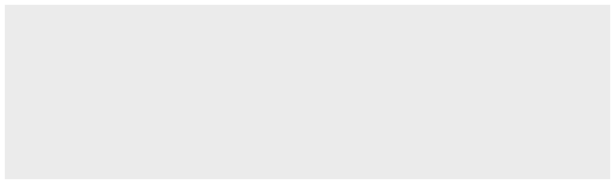

No layers or mapping yet.

```
## Aesthetic mapping:
## <empty>
```

```
## list()
```

Lets add an aesthetic mapping.

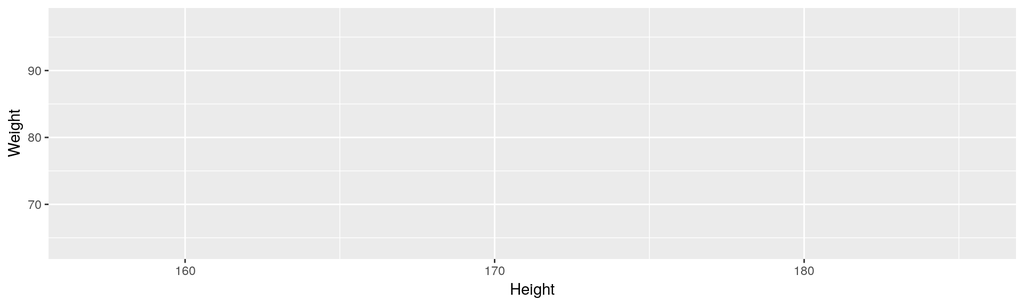

ggplot2 has automatically added scales for x and y based on the range of height and weight values. Still nothing plotted as we haven’t yet specified the type of plot (geom) to add as a layer.

[output not shown]

```
## list()
```

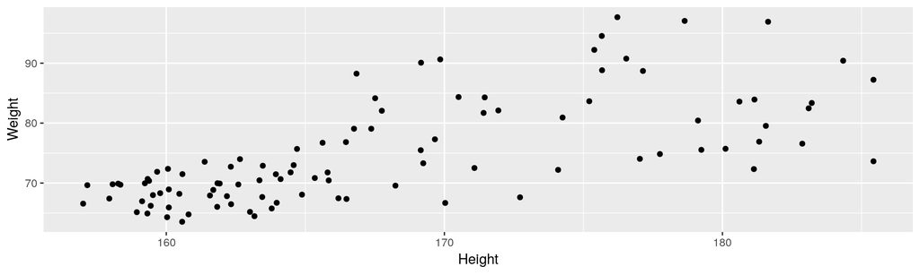

```
## [[1]]
## geom_point: na.rm = FALSE
## stat_identity: na.rm = FALSE
## position_identity
```

Each geom is associated with a statistical transformation, called a stat in ggplot2. This is an algorithm used to calculate new values for the graph. In this case, we are creating a scatter plot and the x and y values don’t need to be transformed, just plotted on the x and y axes, hence `stat_identity` which leaves the data unchanged.

But recall the bar charts we created earlier. How did ggplot2 know what height to make each bar? It counted the number of observations for each categorical value (level) using `stat_count`.

We’ll touch on statistical transformations again a bit later.